# Лабораторная Работа №16

Задачи оптимизации. Модель двухстратегий обслуживания

Козлов В.П.

Российский университет дружбы народов им. Патриса Лумумбы, Москва, Россия

## Докладчик

- Козлов Всеволод Павлович
- НФИбд-02-22
- Российский университет дружбы народов
- [1132226428@pfur.ru]

# Выполнение лабораторной работы

## Цель работы

Реализовать с помощью gpss модель двух стратегий обслуживания и оценить оптимальные параметры.

## Задание

Реализовать с помощью gpss:

- модель с двумя очередями;
- модель с одной очередью;
- изменить модели, чтобы определить оптимальное число пропускных пунктов.

## Постановка задачи

На пограничном контрольно-пропускном пункте транспорта имеются 2 пункта пропуска. Интервалы времени между поступлением автомобилей имеют экспоненциальное распределение со средним значением *μ*. Время прохождения автомобилями пограничного контроля имеет равномерное распределение на интервале [*a*, *b*]. Предлагается две стратегии обслуживания прибывающих автомобилей:

1. автомобили образуют две очереди и обслуживаются соответствующими пунктами пропуска;
2. автомобили образуют одну общую очередь и обслуживаются освободившимся пунктом пропуска. Исходные данные: *μ* = 1, 75 мин, *a* = 1 мин, *b* = 7 мин.

## Построение модели

Целью моделирования является определение:

- характеристик качества обслуживания автомобилей, в частности, средних длин очередей; среднего времени обслуживания автомобиля; среднего времени пребывания автомобиля на пункте пропуска;
- наилучшей стратегии обслуживания автомобилей на пункте пограничного контроля;
- оптимального количества пропускных пунктов.

## Построение модели

В качестве критериев, используемых для сравнения стратегий обслуживания автомобилей, выберем:

- коэффициенты загрузки системы;
- максимальные и средние длины очередей;
- средние значения времени ожидания обслуживания.

## Прибывающие автомобили образуют две очереди и обсл. соответств. пропускными пунктами

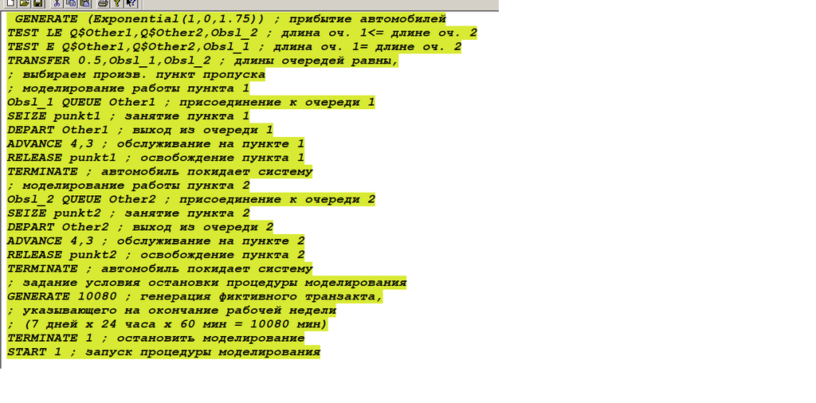

Прибывающие автомобили образуют две очереди и обсл. соответств. пропускными пунктами

## Отчет. Прибывающие автомобили образуют две очереди и обсл. соответств. пропускными пунктами

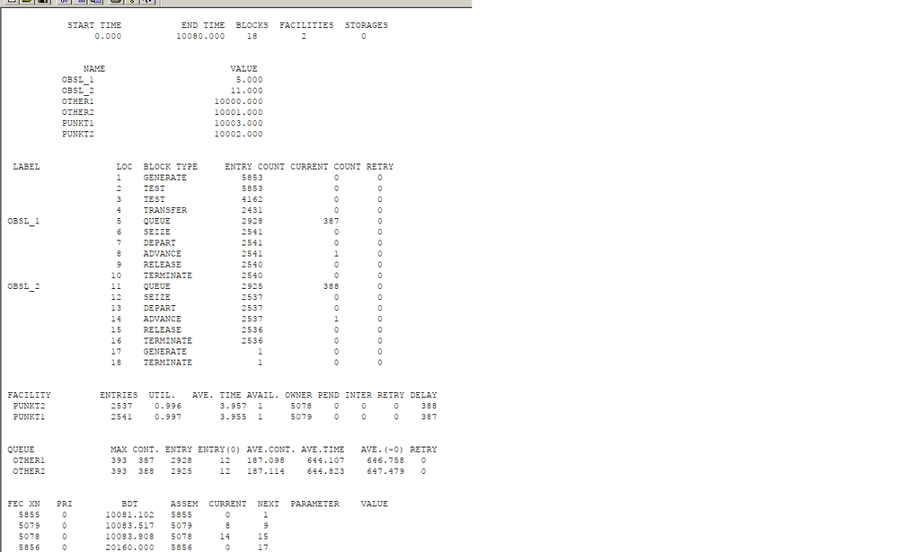

Отчет. Прибывающие автомобили образуют две очереди и обсл. соответств. пропускными пунктами

## Прибывающие автомобили образуют одну очередь и обсл. освободившимися пропускными пунктами

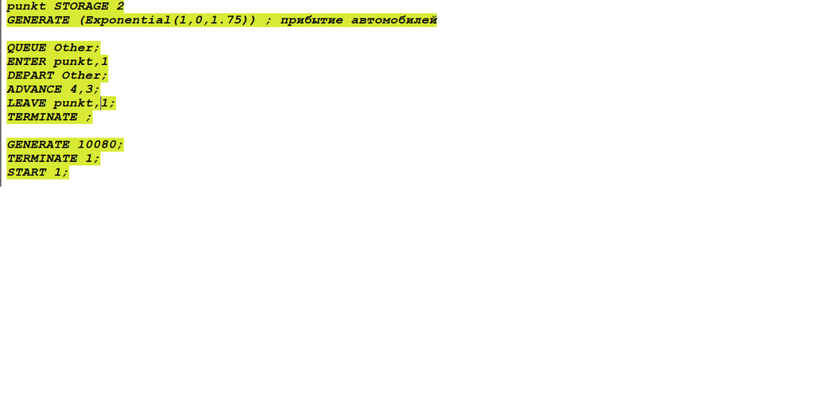

Прибывающие автомобили образуют одну очередь и обсл. освободившимися пропускными пунктами

## Отчет. Прибывающие автомобили образуют одну очередь и обсл. освободившимися пропускными пунктами

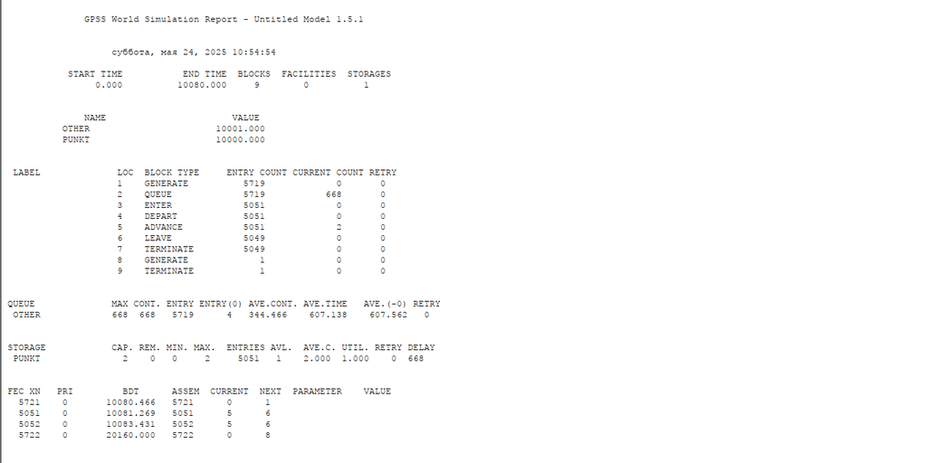

Отчет. Прибывающие автомобили образуют одну очередь и обсл. освободившимися пропускными пунктами

## Сравнение стратегий

| Показатель | стратегия 1 |  |  | стратегия 2 |
| --- | --- | --- | --- | --- |
|  | пункт 1 | пункт 2 | в целом |  |
| Поступило автомобилей | 2928 | 2925 | 5853 | 5719 |
| Обслужено автомобилей | 2540 | 2536 | 5076 | 5049 |
| Коэффициент загрузки | 0,997 | 0,996 | 0,9965 | 1 |
| Максимальная длина очереди | 393 | 393 | 786 | 668 |
| Средняя длина очереди | 187,098 | 187,114 | 374,212 | 344,466 |
| Среднее время ожидания | 644,107 | 644,823 | 644,465 | 607,138 |

## Сравнение стратегий

Анализ результатов моделирования двух систем показывает, что первая модель способна обработать большее количество автомобилей. Однако стоит отметить, что во второй модели разница между числом поступивших и обслуженных машин меньше, что свидетельствует о более эффективной работе системы. Кроме того, коэффициент загрузки для второй модели достигает 1, что означает полное использование всех пропускных пунктов без простоев. Также показатели, связанные с длиной очередей и временем ожидания, во второй стратегии оказались ниже. Это позволяет считать вторую стратегию более предпочтительной.

## Оптимизация модели двух стратегий обслуживания

Изменим модели под следующие критерии:

- коэффициента загрузки прпускных пунктов принадлежат интервалу [0.5; 0.95];
- среднее число автомобилей, одновременно находящихся на контрольно пропускном пункте, не должно превышать 3;
- среднее время ожидания обслуживания не должно превышать 4 мин.

## Модель с одним пунктам (для обеи стратегий)

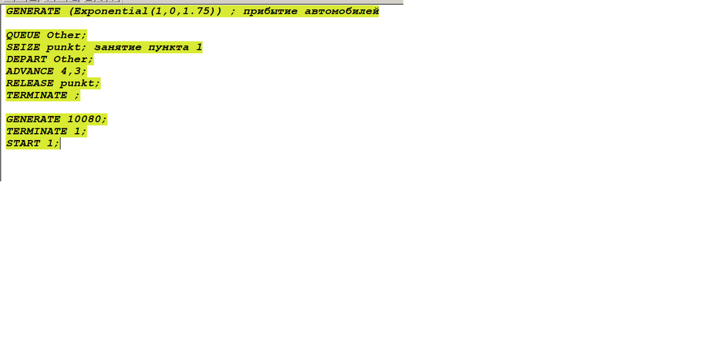

## Отчет. Модель с одним пунктам

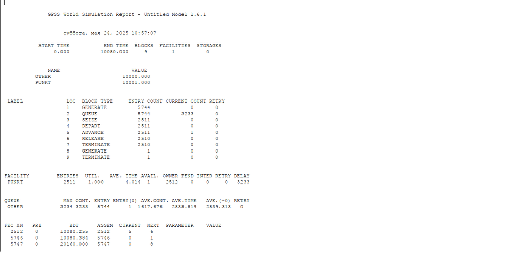

Отчет. Модель с одним пунктам

## Анализ

Здесь модель не проходит ни по одному из критериев, тк коэфиициенты загрузки, размер очереди и среднее время ожидания больше.

## Модель для первой стратегии с 3 пропускными пунктами

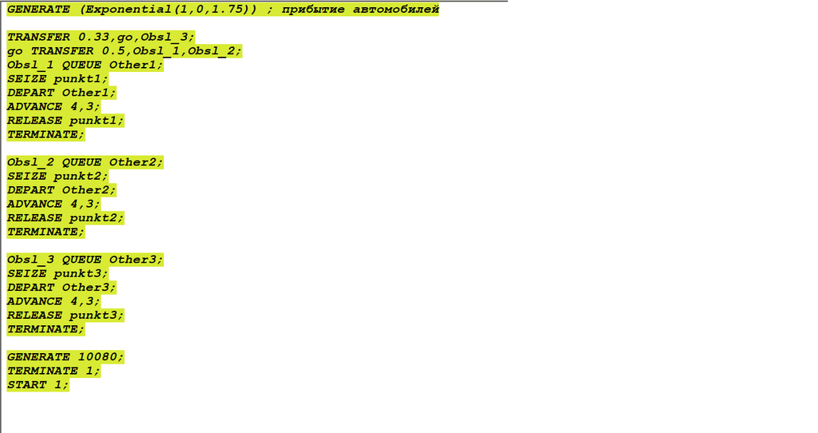

Модель с тремя пунктами

## Отчет. Модель для первой стратегии с 3 пропускными пунктами

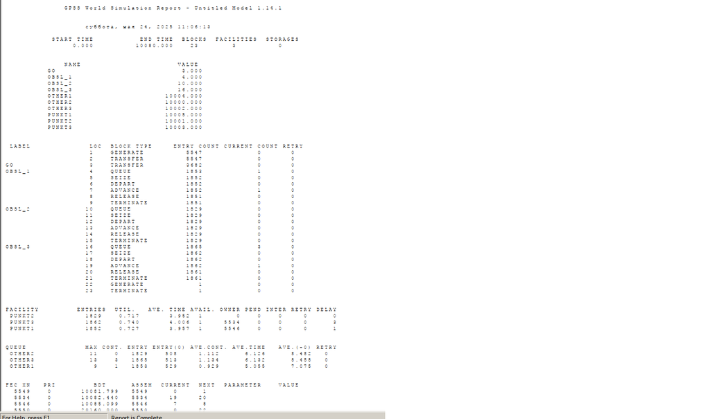

Отчет. Модель с тремя пунктами

## Анализ

Здесь сред кол-во автомобилей в очереди меньше 3 и коэффициента загрузки в нужном диапазоне. Однако сред время ожидания больше 4.

## Модель для первой стратегии с 4 пропускными пунктами

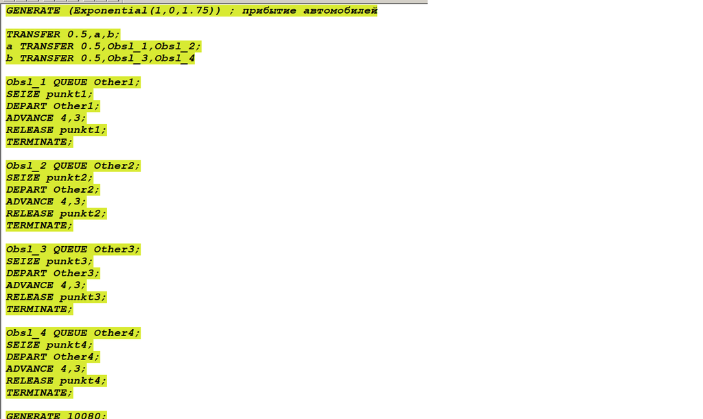

Модель с четырьмя пунктам

## Отчет. Модель для первой стратегии с 4 пропускными пунктами

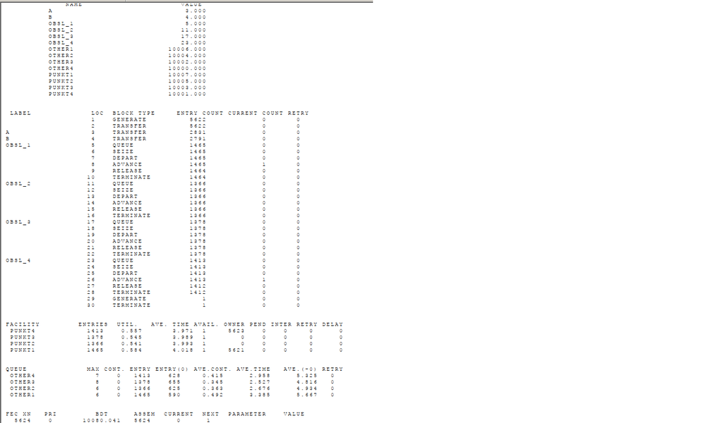

Отчет. Модель с четырьмя пунктам

## Анализ

В этом случае все критерии выполнены, поэтому 4 пункта являются оптимальным количеством для первой стратегии.

## Модель для второй стратегии с 3 пропускными пунктами

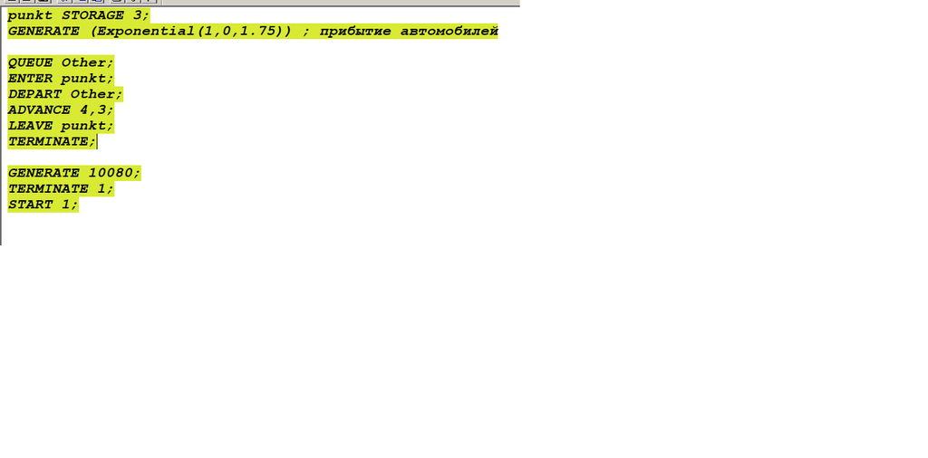

Модель для второй стратегии с 3 пропускными пунктами

## Отчет. Модель для второй стратегии с 3 пропускными пунктами

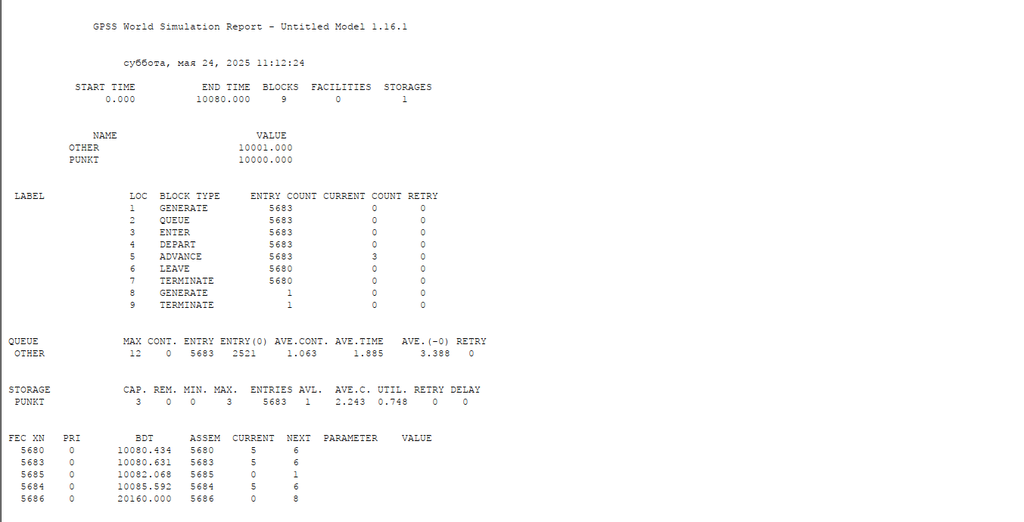

Отчет. Модель для второй стратегии с 3 пропускными пунктами

## Анализ

Все критерии выполняются => модель оптимальна.

## Модель для второй стратегии с 4 пропускными пунктами

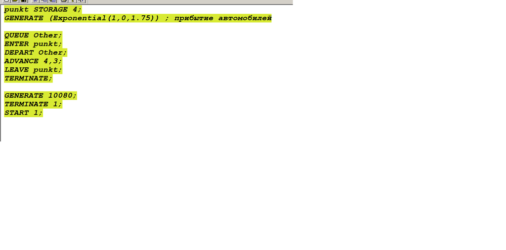

Модель для второй стратегии с 4 пропускными пунктами

## Отчет. Модель для второй стратегии с 4 пропускными пунктами

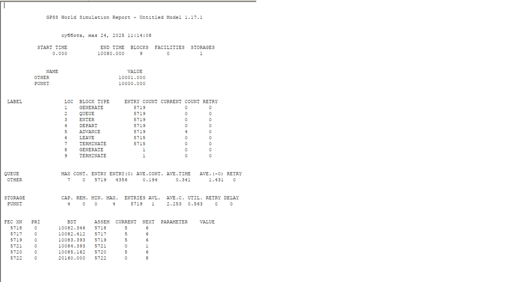

Отчет. Модель для второй стратегии с 4 пропускными пунктами

## Анализ

В данной ситуации все критерии соблюдены, при этом время ожидания и среднее количество автомобилей оказываются ниже, чем во втором варианте стратегии с тремя пунктами. Однако уровень загрузки также снижается, что говорит о возможной избыточности четвёртого пункта пропуска.

## Анализ

Таким образом, на основе проведённого анализа можно заключить, что оптимальное количество пропускных пунктов составляет три при втором типе обслуживания и четыре при первом.

## Выводы

Реализовал с помощью gpss модель двух стратегий обслуживания и оценить оптимальные параметры.